# Fire Damage

```r
library(s20x)
data(fire.df)
head(fire.df, 3)
```

|  | distance | damage |
| --- | --- | --- |
| 1 | 3.4 | 26.2 |
| 2 | 2.6 | 19.6 |
| 3 | 1.8 | 17.8 |

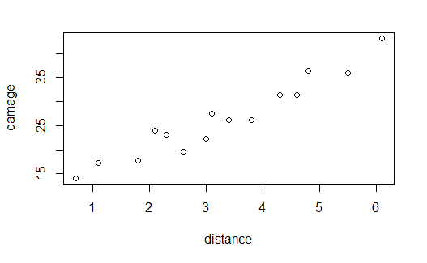

```r
plot(damage~distance, data = fire.df)
```

```r
data.fit = lm(damage~distance, data = fire.df)
```

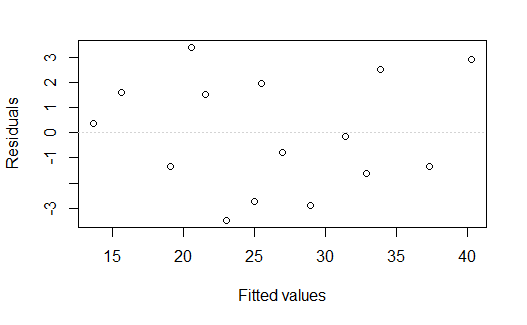

```r
eovcheck(data.fit)
```

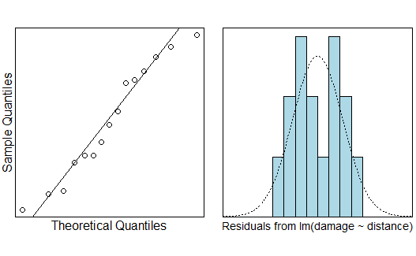

```r
normcheck(data.fit)
```

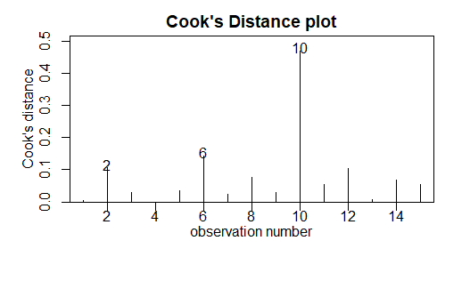

```r
cooks20x(data.fit)
```

```r
summary(data.fit)
```

```
Call:
lm(formula = damage ~ distance, data = fire.df)

Residuals:
    Min      1Q  Median      3Q     Max
-3.4682 -1.4705 -0.1311  1.7915  3.3915

Coefficients:
            Estimate Std. Error t value Pr(>|t|)
(Intercept)  10.2779     1.4203   7.237 6.59e-06 ***
distance      4.9193     0.3927  12.525 1.25e-08 ***
---
Signif. codes:  0 ‘***’ 0.001 ‘**’ 0.01 ‘*’ 0.05 ‘.’ 0.1 ‘ ’ 1

Residual standard error: 2.316 on 13 degrees of freedom
Multiple R-squared:  0.9235,    Adjusted R-squared:  0.9176
F-statistic: 156.9 on 1 and 13 DF,  p-value: 1.248e-08
```

```r
confint(data.fit)
```

```
               2.5 %    97.5 %
(Intercept) 7.209605 13.346252
distance    4.070851  5.767811
```

```r
data.fit2 <- lm(damage~distance, data = fire.df[-10, ])
```

```r
summary(data.fit2)
```

```
Call:
lm(formula = damage ~ distance, data = fire.df[-10, ])

Residuals:
    Min      1Q  Median      3Q     Max
-3.4205 -1.3871 -0.2625  1.3800  3.2945

Coefficients:
            Estimate Std. Error t value Pr(>|t|)
(Intercept)  11.1019     1.4417    7.70 5.55e-06 ***
distance      4.5841     0.4279   10.71 1.69e-07 ***
---
Signif. codes:  0 ‘***’ 0.001 ‘**’ 0.01 ‘*’ 0.05 ‘.’ 0.1 ‘ ’ 1

Residual standard error: 2.193 on 12 degrees of freedom
Multiple R-squared:  0.9053,    Adjusted R-squared:  0.8975
F-statistic: 114.8 on 1 and 12 DF,  p-value: 1.692e-07
```

```r
pred.df = data.frame(distance = c(1,4))
```

```r
predict(data.fit, pred.df, interval = "prediction")
```

```
       fit      lwr      upr
1 15.19726  9.67879 20.71573
2 29.95525 24.75100 35.15951
```

**Methods and Assumption Checks**

A scatter plot of damage vs distance showed a linear relationship so a linear model was fitted.

Th equality of variance and normality assumptions appear to be satisfied. A slight trend in residual plot wa sobserved but does not appear to be of major concern. We have a random sample of fires so the indepence assumption should also be satisfied.

Observation 10 showed up of concern in the Cooks plot but removing it didn’t change the parameters by one standard error, so it wasn’t dropped.

Our final model is damagei = B0 + B1 * distancei + ei where ei ~iid N(0, sd^2).

**Executive Summary**

An insurace company wanted to be able to predict fire damage in dollars in relation to the distance away the house is from a fire station.

We find that the further away a house is from a fire station the more fire damage it experiences.

Our model explains 92% of the variation in house fire damage and should therefore be a reasonable model for prediction.

Using our model, we predict that if a new fire occurs in a house 1 mile away from the fire station the damage will be between $9700 and % 20700. For a house that is 4 miles away from the fire station, the we predict the damage will be between $24800 and $35200.